# Ecological Genomics Tutorials: Population & Landscape Genomics 8

October 04, 2023

# Learning Objectives for 10/04/23

# Geneotype-Enviroment Association (GEA) on selection outlier loci!

1. Revisit pcANGSD selection scan to output genetic PCs and outlier loci list
2. Extract climate data for red spruce localities and summarize with PCA
3. Run genotype-environment association (GEA) analysis running

We’ve now learned about outlier loci that show extreme population structure along genetic PC axes. These are loci that tend to have high Fst (population structure) suggestive of selection and local adaptation. But how does this relate to different aspects of the environment? How do we know what environmental gradients might be responsible for driving this population differentiation? Where’s the “landscape” in all this genomics stuff?

That’s where GEA comes in – shorthand for **“Genotype-Environment Association”**.

The whole idea behind GEA is to look for loci that show strong associations between allele frequencies (aka, genotypes) and environmental gradients (aka, climate).

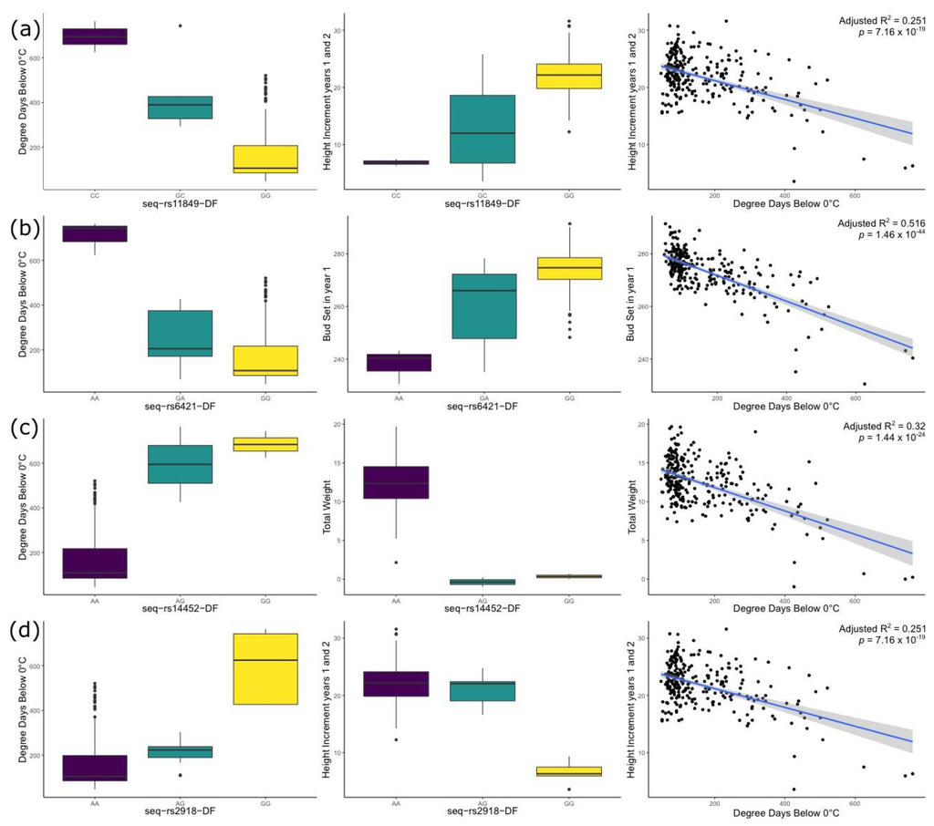

*Figure from: De La Torre, A.R., Wilhite, B., Puiu, D., St. Clair, J.B., Crepeau, M.W., Salzberg, S.L., Langley, C.H., Allen, B. and Neale, D.B., 2021. Dissecting the polygenic basis of cold adaptation using genome-wide association of traits and environmental data in Douglas-fir. Genes, 12(1), p.110.*

There’s a substantial literature on GEA methods in landscape genomics, but a good background paper is [Rellstab et al. (2015)](https://onlinelibrary.wiley.com/doi/full/10.1111/mec.13322).

For any GEA analysis, you essentially need two things:

1. Genotype data from individuals sampled across one or more environmental gradients.
2. Environmental data (like climate) you want to test as drivers of the selection on allele frequencies.

Our approach will not be to test every SNP locus with GEA, but rather just test the outlier loci we identified from pcANGSD as showing evidence of selection. By pairing that with the GEA, we can refine our inference of selection by asking if these outliers are likely selected on as a result of one or more environmental gradients.

### 1. Re-visit the pcANGSD results to get necessary outlier info and covariates

(a). Last session, we produced a list of outlier loci, but we had some trouble applying our significance cutoff and exporting our list of outlier loci. That’s take a second and make sure that’s good now.

In R:

```
library(RcppCNPy) # for reading python numpy (.npy) files

setwd("")

list.files()

### read in selection statistics (these are chi^2 distributed)

s<-npyLoad("allRS_poly.selection.npy")

# convert test statistic to p-value
pval <- as.data.frame(1-pchisq(s,1))
names(pval) = c("p_PC1","p_PC2")

## read positions
p <- read.table("allRS_poly_mafs.sites",sep="\t",header=T, stringsAsFactors=T)
dim(p)

p_filtered = p[which(p$kept_sites==1),]
dim(p_filtered)

# get all the outliers with p-values below some cutoff
cutoff=1e-3

outliers_PC1 <- p_filtered[which(pval$p_PC1<cutoff),c("chromo","position")]

# how many outlier loci < the cutoff?
dim(outliers_PC1)[1]


# write them out to a file
write.table(outliers_PC1,
  "allRS_poly_outliers_PC1.txt",
  sep=":",
  quote=F,
  row.names=F,
  col.names=F)
```

(b). We also want to export the scores for each of our individuals along the genetic PC1 and PC2 axes. We’ll use these scores as covariates in our GEA model to control for the overall effects of population structure when testing for climate association.

```
COV <- as.matrix(read.table("allRS_poly.cov"))

PCA <- eigen(COV)

data=as.data.frame(PCA$vectors)
data=data[,c(1:2)] # the second number here is the number of PC axes you want to keep

write.table(data,
            "allRS_poly_genPC1_2.txt",
            sep="\t",
            quote=F,
            row.names=F,
            col.names=F)
```

### 2. Getting `Bioclim` climate data for our red spruce samples

We can also use R to query the [Worldclim climate database](https://www.worldclim.org/data/worldclim21.html) and pull out the bioclim variables for each of our samples based on their lat/longs.

Remember, the following code is in R, not bash ;)

```
# You made need to use "install.packages" if you don't have some of the below libraries already

library(raster)
library(FactoMineR)
library(factoextra)
library(corrplot)

setwd("")

bio <- getData("worldclim",var="bio",res=10)

coords <- read.csv("https://www.uvm.edu/~kellrlab/forClass/colebrookSampleMetaData.csv", header=T)

The chunk below refers to your bamlist file that you transferred during last week's PCA/admixture analysis.  It should be the same one you want to use here -- if your sample list for analysis changes in the future, you'll need a different bamlist!

names <- read.table("allRS_bam.list")
names <- unlist(strsplit(basename(as.character(names[,1])), split = ".sorted.rmdup.bam"))
split = strsplit(names, "_")
pops <- data.frame(names[1:95], do.call(rbind, split[1:95]))
names(pops) = c("Ind", "Pop", "Row", "Col")

angsd_coords <- merge(pops, coords, by.x="Ind", by.y="Tree")

points <- SpatialPoints(angsd_coords[c("Longitude","Latitude")])

clim <- extract(bio,points)

angsd_coords_clim <- cbind.data.frame(angsd_coords,clim)
str(angsd_coords_clim)
```

#### And just like that, we’ve got Bioclim data for our samples!

Now, we don’t want to test all 19 variables in our GEA, but rather just one or a few that seem to capture the climate gradients in our samples.

For this, we can use PCA on the climate data (so, an environmental, not a genetic PCA in this case). Using the cliamte PCA can then let us see which variables most strongly define the climate space of red spruce, and we can then use these for our GEA test.

#### In R:

```
# Make the climate PCA:

clim_PCA = PCA(angsd_coords_clim[,15:33], graph=T)

# Get a screeplot of cliamte PCA eigenvalues

fviz_eig(clim_PCA)

# What is the climate PCA space our red spruce pops occupy?

fviz_pca_biplot(clim_PCA,
             geom.ind="point",
             col.ind = angsd_coords_clim$Latitude,
             gradient.cols = c("#00AFBB", "#E7B800", "#FC4E07"),
             title="Climate PCA (Bioclim)",
             legend.title="Latitude")

# Which variables show the strongest correlation on the first 2 climate PC axes?

dimdesc(clim_PCA)[1:2]
```

Let’s export the Bioclim variable most important for each of these axes:

```
# Replace "XX" with your bio variable most significant on climate PC1:

write.table(scale(angsd_coords_clim["bioXX"]),
            "allRS_bioXX.txt",
            sep="\t",
            quote=F,
            row.names = F,
            col.names=F)


# Replace "YY" with your bio variable most significant on climate PC2:

write.table(scale(angsd_coords_clim["bioYY"]),
            "allRS_bioYY.txt",
            sep="\t",
            quote=F,
            row.names = F,
            col.names=F)
```

After you’ve written this file out, use **FileZilla** to transfer all your new files over to the server and into your `~/myresults/ANGSD` folder.

### 2. Running the GEA to test which outlier loci are associated with climate

Since we are running the GEA analysis on just our oultiers (=candidates for selection), it will be pretty fast! One can also run a genome-wide GEA, which takes much longer…but doable for future studies ;)

We’ll use ANGSD again to test for associations between allele frequencies and the bioclim variables while using genotype likelihoods to account for uncertainty. The ANGSD routine we’ll use is called `doAsso` which stands for “do Association”. It has it’s own [manual page on ANGSD’s website](http://www.popgen.dk/angsd/index.php/Association)

ANGSD `doAsso` requires genotype *probabilities* (yes, these are slightly different mathematical than genotype *likelihoods*), which means we’ll need to call the initial set of ANGSD commands to import the bam’s and filter them before sending the probabilities to the `doAsso` function.

```
# your usual bash header

# add some notes


REF="/netfiles/ecogen/PopulationGenomics/ref_genome/Pabies1.0-genome_reduced.fa"

SUFFIX="allRS"

# Let's start with bio10; can do others as time permits...
BIOVAR=""

# path to the red spruce bam files
INPUT="/netfiles/ecogen/PopulationGenomics/fastq/red_spruce/cleanreads/bam"

OUTPUT=

# make the bamlist files
ls ${INPUT}/*sorted.rmdup.bam >${OUTPUT}/${SUFFIX}_bam.list


# Run ANGSD to estimate the genotype probabilities and perform the GEA:

ANGSD -b ${OUTPUT}/${SUFFIX}_bam.list \
-ref ${REF} -anc ${REF} \
-out ${OUTPUT}/${SUFFIX}_${BIOVAR} \
-nThreads 1 \
-remove_bads 1 \
-C 50 \
-baq 1 \
-minMapQ 20 \
-minQ 20 \
-GL 1 \
-doCounts 1 \
-minInd 47 \
-setMinDepthInd 1 \
-setMaxDepthInd 40 \
-skipTriallelic 1 \
-doMajorMinor 1 \
-doMaf 1 \
-SNP_pval 1e-6 \
-minMaf 0.05 \
-doPost 1 \
-doAsso 5 \
-yQuant ${OUTPUT}/allRS_${BIOVAR}.txt \
-rf ${OUTPUT}/${SUFFIX}_outliers_PC1.txt \
-cov ${OUTPUT}/${SUFFIX}_genPC1_2.txt
```

That’s a lot of options for ANGSD!

Most of these are identical to what I used for calling the genotype likelihoods (beagle files) that we used as input into pcANGSD. But I wanted to give you all the options and their meaning ([see also the ANGSD manual online](http://www.popgen.dk/angsd/index.php/ANGSD) so you could have them in case you need to change anything.

Those last 5 lines are the important part for the GEA:

| Code option | Meaning |
| --- | --- |
| `doPost 1` | compute genotype probabilities |
| `doAsso 5` | perform the GEA association test |
| `-yQuant` | the input environmental variable to test (can only test 1 env at a time) |
| `rf` | the list of outlier loci to test, in chromosome:position format |
| `-cov` | the list of covariates, in this case, the genetic PC axes describing the pop structure |

You’ll also notice that we do this just on loci that are present in at least 5% frequency across the entire set of samples (`-minMaf 0.05`)

Save your script as `ANGSD_GEA.sh`

It will run fast, so probably you don’t need a `tmux` session.

If we peek inside this file, you’ll see something like this:

`zcat allRS_poly_bio10.lrt0.gz | head`

```
Chromosome  Position    Major   Minor   Frequency   N   LRTscore    high_WT/HE/HO   LRTem   beta    SE  emIter
MA_65255    1119    G   A   0.143663    95  -999.000000 10/1/0  nan nan nan 0
MA_9957507  2373    G   T   0.118974    95  -999.000000 12/2/0  nan nan nan 0
MA_10429602 2561    T   C   0.170879    95  -999.000000 20/4/0  nan nan nan 0
MA_10429602 2590    A   G   0.121700    95  -999.000000 15/0/0  nan nan nan 0
MA_10430260 11653   T   C   0.096735    95  -999.000000 64/4/0  nan nan nan 0
MA_1135 12714   C   A   0.300374    95  0.040177    14/15/2 nan nan nan 0
MA_8953275  2254    T   A   0.254357    95  -999.000000 3/2/6   nan nan nan 0
MA_10435716 4986    T   C   0.182536    95  -999.000000 1/3/0   nan nan nan 0
MA_593911   2820    A   G   0.058739    95  -999.000000 82/4/0  nan nan nan 0
```

The first 6 columns should be mostly self-explanatory by now. The later columns mean:

| Column | Meaning |
| --- | --- |
| `LRTscore` | Likelihood Ratio Test (LRT) of whether the SNP is associated with climate |
| `high_WT/HE/HO` | The counts of homozygous (wildtype):heterozygous:homozygous genotypes |
| `LRTem` | Another version of the likelihood ratio test (this is the one used to compute significance) |
| `beta` | The slope of minor allele frequencies along the climate gradient |
| `SE` | The standard error of the slope |
| `emIter` | Number of iterations of the EM algorithm used to test for significance in the GEA |

You’ll notice that most (maybe all?) of the head on this file has lots of ‘nan’. That means those SNPs were not significant (i.e., had no significant association between allele frequencies and the climate gradient).

We can quickly find the loci that *ARE* signficant by doing an “inverted” grep search that finds all the lines in the file that *DON’T* have a match to your search term. Clever, eh?

`zcat allRS_poly_bio10.lrt0.gz | grep -v "nan" | head`

```
Chromosome  Position    Major   Minor   Frequency   N   LRTscore    high_WT/HE/HO   LRTem   beta    SE  emIter
MA_122595   9205    G   A   0.178944    95  4.075774    41/11/05.321326 -0.640934   0.249910    23
MA_5911667  371 A   G   0.221774    95  8.997344    25/15/011.085109    -0.765536   0.196047    18
MA_118138   1326    T   C   0.213717    95  6.004392    47/13/25.974007 0.399418    0.214912    2
MA_472677   1618    A   C   0.131357    95  5.845219    65/13/05.833940 0.568727    0.329935    2
MA_305431   2240    A   C   0.171533    95  6.603277    52/11/06.529913 0.504134    0.298265    2
MA_42276    14661   G   A   0.199746    95  11.767473   29/13/014.041176    -0.881066   0.177973    26
MA_2314 6247    T   A   0.202935    95  9.714111    33/12/0 10.471330   -0.625151   0.171075    9
```

- *How many significant loci?* (**Hint:** remove the ‘head’ command and pipe to a different command that counts lines in the file)
- *Do the allele frequencies seem to consistently have positive or negative slopes? What does that mean for the climate gradient you tested?*
- *You could find out what genes and their function are associated with this set of loci using the code we developed at the end of Day 7.* (**Hint:** Here, you’d be cutting out the first column containing the contig info and using that to grep out the genes from the reference genome annotation. This could then be used at plantgenie.org to look at gene annotationa and function!)